# Midterm Data Exercise #1 - Continuous Outcomes

### Part 2

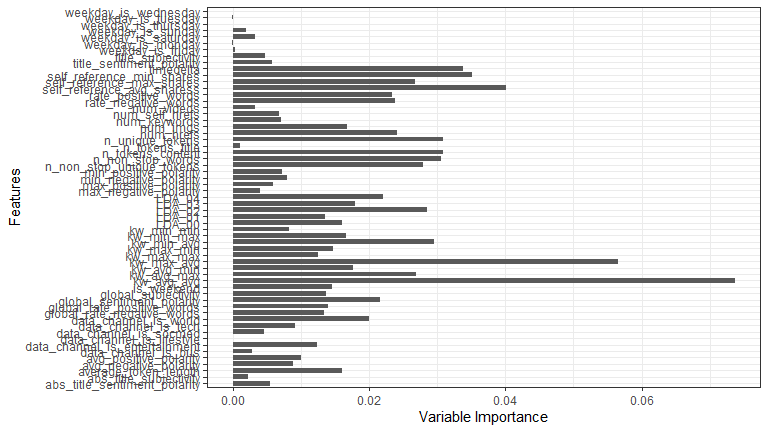

```r
p1p2_m <- ranger(data = strain_df_p1, formula = shares ~ ., mtry = 8,
    num.trees = 1000, importance = "permutation")

p1p2_df <- data.frame(p1p2_m$variable.importance)
p1p2_df$var <- rownames(p1p2_df)
p1p2_df <- p1p2_df %>%
    rename(var_imp = p1p2_m.variable.importance)

ggplot(data = p1p2_df, aes(x = var, y = var_imp)) + geom_bar(stat = "identity",
    width = 0.75) + coord_flip() + labs(x = "Features", y = "Variable Importance") +
    theme_bw()
```

```r
p1p2_df %>%
    arrange(desc(var_imp)) %>%
    head(2)  #most important
```

|  | var_imp | var |
| --- | --- | --- |
| kw_avg_avg | 0.0737480 | kw_avg_avg |
| kw_max_avg | 0.0564865 | kw_max_avg |

```r
p1p2_df %>%
    arrange(desc(var_imp)) %>%
    tail(4)  #least important
```

|  | var_imp | var |
| --- | --- | --- |
| data_channel_is_lifestyle | -0.0000069 | data_channel_is_lifestyle |
| weekday_is_thursday | -0.0000679 | weekday_is_thursday |
| weekday_is_monday | -0.0001399 | weekday_is_monday |
| weekday_is_tuesday | -0.0001567 | weekday_is_tuesday |

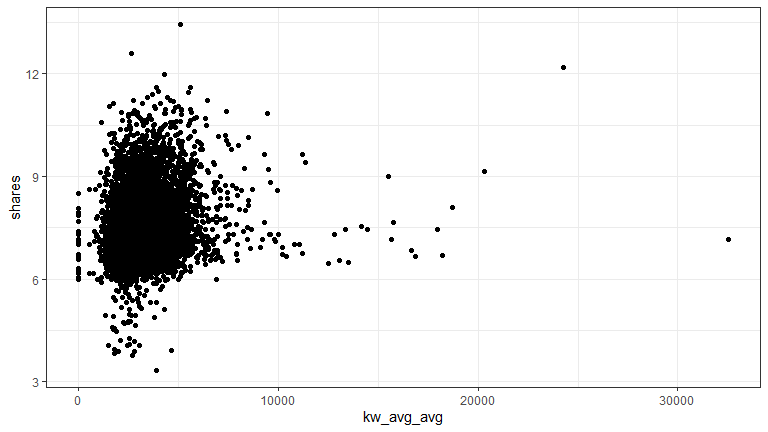

```r
# true relationships
ggplot(data = strain_df_p1) + geom_point(aes(x = kw_avg_avg,
    y = shares)) + theme_bw()
```

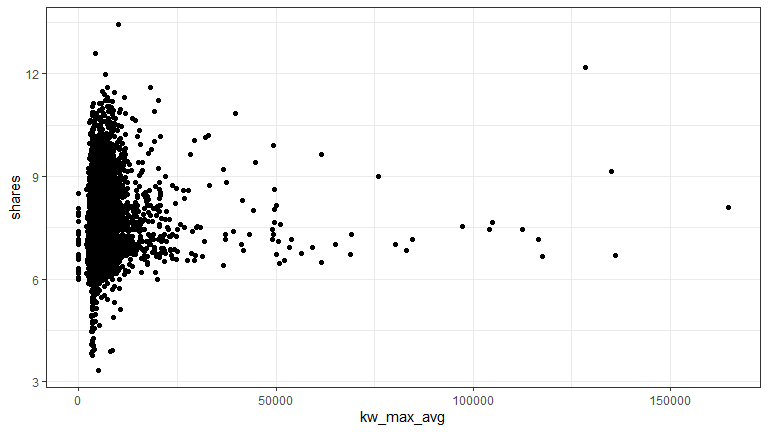

```r
ggplot(data = strain_df_p1) + geom_point(aes(x = kw_max_avg,
    y = shares)) + theme_bw()
```

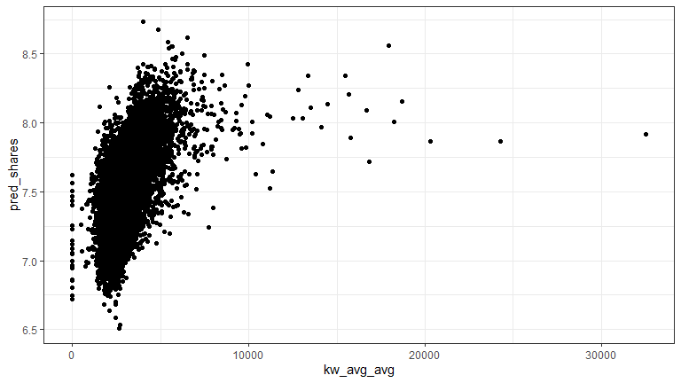

```r
# prediction relationships
pred_r <- data.frame(kw_avg_avg = strain_df_p1$kw_avg_avg, kw_max_avg = strain_df_p1$kw_max_avg,
    pred_shares = p1p2_m$predictions)

ggplot(data = pred_r) + geom_point(aes(x = kw_avg_avg, y = pred_shares)) +
    theme_bw()
```

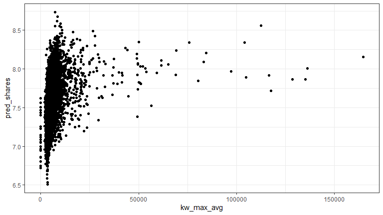

```r
ggplot(data = pred_r) + geom_point(aes(x = kw_max_avg, y = pred_shares)) +
    theme_bw()
```

## Question 2 - Building a Big Predictive Model (25 pts.)

```r
# sample training dataset
set.seed(123)
sam_train <- as.numeric(sample(x = nrow(train_df), size = 30000,
    replace = FALSE))
sam_test <- setdiff(seq(1, 35000, 1), sam_train)
strain_df_p2 <- train_df[sam_train, ]
stest_df_p2 <- train_df[sam_test, ]

# transform variable shares
strain_df_p2$shares <- log(strain_df_p2$shares)
stest_df_p2$shares <- log(stest_df_p2$shares)

# drop variable url
strain_df_p2 <- strain_df_p2[, -1]
stest_df_p2 <- stest_df_p2[, -1]
```

```r
# According to problem 1, we take for granted that 8 is a
# good choice for the number of variables considered for
# each bootstrap tree in the random forest model in terms
# of OOB error and MSE on the heldout data set.
p2_rf_m <- ranger(data = strain_df_p2, formula = shares ~ .,
    mtry = 8, num.trees = 1000)
# OOB error
p2_rf_m$prediction.error
```

```
## [1] 0.724111
```

```r
# out of sample mse
mse(predict(p2_rf_m, data = stest_df_p2)$predictions, stest_df_p2$shares)
```

```
## [1] 0.6879522
```

```r
# According to problem 1 part 2, we can choose a subset of
# important variables to fit a GAM model, since the full
# predictor GAM model will lead to multicollinearity
# problem. Similarly, the full OLS linear regression model
# has the same problem. However, since the GAM model always
# has better performance over OLS linear regression model
# in terms of predictive accuracy, we decide not to try it.
p1p2_df %>%
    arrange(desc(var_imp))
```

|  | var_imp | var |
| --- | --- | --- |
| kw_avg_avg | 0.0737480 | kw_avg_avg |
| kw_max_avg | 0.0564865 | kw_max_avg |
| self_reference_avg_sharess | 0.0400388 | self_reference_avg_sharess |
| self_reference_min_shares | 0.0350740 | self_reference_min_shares |
| timedelta | 0.0337174 | timedelta |
| n_tokens_content | 0.0308149 | n_tokens_content |
| n_unique_tokens | 0.0307875 | n_unique_tokens |
| n_non_stop_words | 0.0304873 | n_non_stop_words |
| kw_min_avg | 0.0294978 | kw_min_avg |
| LDA_02 | 0.0285227 | LDA_02 |
| n_non_stop_unique_tokens | 0.0278694 | n_non_stop_unique_tokens |
| kw_avg_max | 0.0267990 | kw_avg_max |
| self_reference_max_shares | 0.0267430 | self_reference_max_shares |
| num_hrefs | 0.0241139 | num_hrefs |
| rate_negative_words | 0.0237314 | rate_negative_words |
| rate_positive_words | 0.0233558 | rate_positive_words |
| LDA_04 | 0.0220172 | LDA_04 |
| global_sentiment_polarity | 0.0215800 | global_sentiment_polarity |
| data_channel_is_world | 0.0199331 | data_channel_is_world |
| LDA_03 | 0.0179470 | LDA_03 |
| kw_avg_min | 0.0176533 | kw_avg_min |
| num_imgs | 0.0167116 | num_imgs |
| kw_min_max | 0.0165383 | kw_min_max |
| average_token_length | 0.0159831 | average_token_length |
| LDA_00 | 0.0159492 | LDA_00 |
| kw_max_min | 0.0146759 | kw_max_min |
| is_weekend | 0.0144860 | is_weekend |
| global_rate_positive_words | 0.0138548 | global_rate_positive_words |
| global_subjectivity | 0.0136805 | global_subjectivity |
| LDA_01 | 0.0135077 | LDA_01 |
| global_rate_negative_words | 0.0133512 | global_rate_negative_words |
| kw_max_max | 0.0123928 | kw_max_max |
| data_channel_is_entertainment | 0.0122730 | data_channel_is_entertainment |
| avg_positive_polarity | 0.0099162 | avg_positive_polarity |
| data_channel_is_tech | 0.0090160 | data_channel_is_tech |
| avg_negative_polarity | 0.0087477 | avg_negative_polarity |
| kw_min_min | 0.0081683 | kw_min_min |
| min_negative_polarity | 0.0079655 | min_negative_polarity |
| min_positive_polarity | 0.0072172 | min_positive_polarity |
| num_keywords | 0.0070545 | num_keywords |
| num_self_hrefs | 0.0067018 | num_self_hrefs |
| max_positive_polarity | 0.0058934 | max_positive_polarity |
| title_sentiment_polarity | 0.0057652 | title_sentiment_polarity |
| abs_title_sentiment_polarity | 0.0054733 | abs_title_sentiment_polarity |
| title_subjectivity | 0.0046397 | title_subjectivity |
| data_channel_is_socmed | 0.0044986 | data_channel_is_socmed |
| max_negative_polarity | 0.0039328 | max_negative_polarity |
| weekday_is_saturday | 0.0031699 | weekday_is_saturday |
| num_videos | 0.0031371 | num_videos |
| data_channel_is_bus | 0.0027522 | data_channel_is_bus |
| abs_title_subjectivity | 0.0021647 | abs_title_subjectivity |
| weekday_is_sunday | 0.0019280 | weekday_is_sunday |
| n_tokens_title | 0.0009403 | n_tokens_title |
| weekday_is_friday | 0.0002669 | weekday_is_friday |
| weekday_is_wednesday | 0.0000147 | weekday_is_wednesday |
| data_channel_is_lifestyle | -0.0000069 | data_channel_is_lifestyle |
| weekday_is_thursday | -0.0000679 | weekday_is_thursday |
| weekday_is_monday | -0.0001399 | weekday_is_monday |
| weekday_is_tuesday | -0.0001567 | weekday_is_tuesday |

```r
p2_gam <- gam(data = strain_df_p2, family = gaussian(), shares ~
    s(kw_avg_avg) + s(kw_max_avg) + s(self_reference_avg_sharess))
# in sample mse
mse(predict.gam(p2_gam, strain_df_p2), strain_df_p2$shares)
```

```
## [1] 0.7916581
```

```r
# out of sample mse
mse(predict.gam(p2_gam, stest_df_p2), stest_df_p2$shares)
```

```
## [1] 0.7602863
```

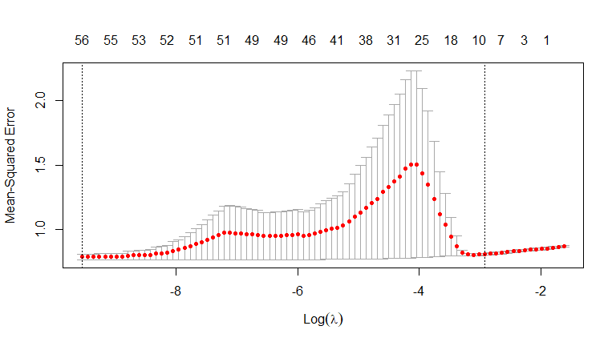

```r
p2_x <- data.matrix(strain_df_p2[, -60])
p2_y <- data.matrix(strain_df_p2[, 60])

p2_cv_lassom <- cv.glmnet(x = p2_x, y = p2_y, family = "gaussian",
    alpha = 1, nfolds = 10, type.measure = "mse")
plot(p2_cv_lassom)
```

```r
print(p2_cv_lassom)
```

```
##
## Call:  cv.glmnet(x = p2_x, y = p2_y, type.measure = "mse", nfolds = 10,      family = "gaussian", alpha = 1)
##
## Measure: Mean-Squared Error
##
##      Lambda Index Measure       SE Nonzero
## min 0.00007    86  0.7859 0.022560      56
## 1se 0.05367    15  0.8078 0.008987       7
```

```r
p2_optimal_lassom <- glmnet(x = p2_x, y = p2_y, family = "gaussian",
    alpha = 1, lambda = p2_cv_lassom$lambda.min)
# in sample mse
mse(p2_y, predict(p2_optimal_lassom, newx = p2_x))
```

```
## [1] 0.7613149
```

```r
# out of sample mse
mse(stest_df_p2$shares, predict(p2_optimal_lassom, newx = data.matrix(stest_df_p2[,
    -60])))
```

```
## [1] 0.734112
```

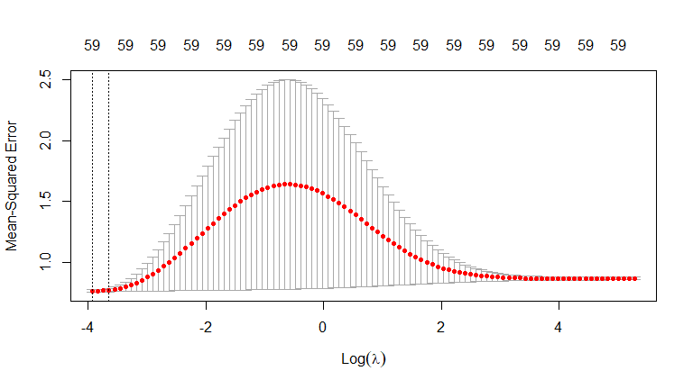

```r
p2_cv_ridgem <- cv.glmnet(x = p2_x, y = p2_y, family = "gaussian",
    alpha = 0, nfolds = 10, type.measure = "mse")
plot(p2_cv_ridgem)
```

```r
print(p2_cv_ridgem)
```

```
##
## Call:  cv.glmnet(x = p2_x, y = p2_y, type.measure = "mse", nfolds = 10,      family = "gaussian", alpha = 0)
##
## Measure: Mean-Squared Error
##
##      Lambda Index Measure      SE Nonzero
## min 0.01974   100  0.7663 0.01100      59
## 1se 0.02610    97  0.7725 0.01337      59
```

```r
p2_optimal_ridgem <- glmnet(x = p2_x, y = p2_y, family = "gaussian",
    alpha = 0, lambda = p2_cv_ridgem$lambda.min)
# in sample mse
mse(p2_y, predict(p2_optimal_ridgem, newx = p2_x))
```

```
## [1] 0.7625545
```

```r
# out of sample mse
mse(stest_df_p2$shares, predict(p2_optimal_ridgem, newx = data.matrix(stest_df_p2[,
    -60])))
```

```
## [1] 0.7350761
```

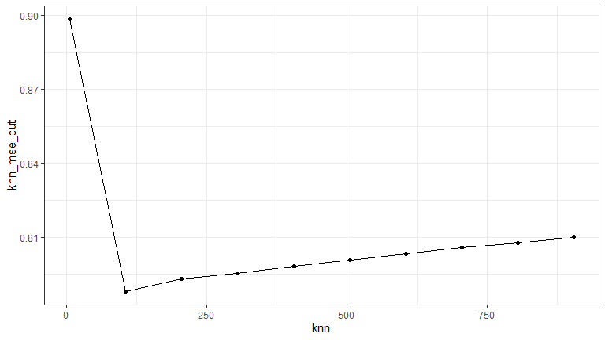

```r
# The full predictor KNN model does not perform well here,
# which is probably caused by the curse of dimensionality
# problem.
knn <- seq(5, 1000, 100)
knn_mse_out <- c()

for (i in knn) {
    knn_m <- knn.reg(train = p2_x, test = stest_df_p2[, -60],
        y = p2_y, k = i)
    knn_mse_out <- c(knn_mse_out, mse(knn_m$pred, stest_df_p2$shares))
}

p2_knn_df <- data.frame(knn, knn_mse_out)
ggplot(data = p2_knn_df) + geom_point(aes(x = knn, y = knn_mse_out)) +
    geom_line(aes(x = knn, y = knn_mse_out)) + theme_bw()
```

```r
# conclusion
p2_mse_in_sample <- c(mse(predict.gam(p2_gam, strain_df_p2),
    strain_df_p2$shares), mse(p2_y, predict(p2_optimal_lassom,
    newx = p2_x)), mse(p2_y, predict(p2_optimal_ridgem, newx = p2_x)))
p2_mse_out_sample <- c(mse(predict.gam(p2_gam, stest_df_p2),
    stest_df_p2$shares), mse(stest_df_p2$shares, predict(p2_optimal_lassom,
    newx = data.matrix(stest_df_p2[, -60]))), mse(stest_df_p2$shares,
    predict(p2_optimal_ridgem, newx = data.matrix(stest_df_p2[,
        -60]))))
p2_m <- c("GAM", "RIDGE", "LASSO")
data.frame(model = p2_m, mse_in_sample = p2_mse_in_sample, mse_out_sample = p2_mse_out_sample)
```

[output not shown]

```r
p2_m <- c("random forest", "GAM", "LASSO", "RIDGE", "KNN")
# manually calculated
p2_runtime_seconds <- c(198, 11, 8, 5, 27)
data.frame(p2_m, p2_runtime_seconds)
```

| p2_m | p2_runtime_seconds |
| --- | --- |
| random forest | 198 |
| GAM | 11 |
| LASSO | 8 |
| RIDGE | 5 |
| KNN | 27 |

As shown in the table, the runtime in random forest (our optimal model) is the highest even though it is the best predictive model. KNN model ranks the second highest, whereas GAM, LASSO, and RIDGE models are relatively quick.

```r
p2_results <- data.frame(ID = test_df$ID, p2_pred = predict(p2_rf_m,
    data = test_df)$predictions)
write.csv(p2_results, file = "Midterm1Q2_Predictions.csv", row.names = FALSE)
```

## Question 3 - Interpreting Your Big Predictive Model (7 pts.)

```r
p3_m <- ranger(data = strain_df_p2, formula = shares ~ ., mtry = 8,
    num.trees = 1000, importance = "permutation")
```

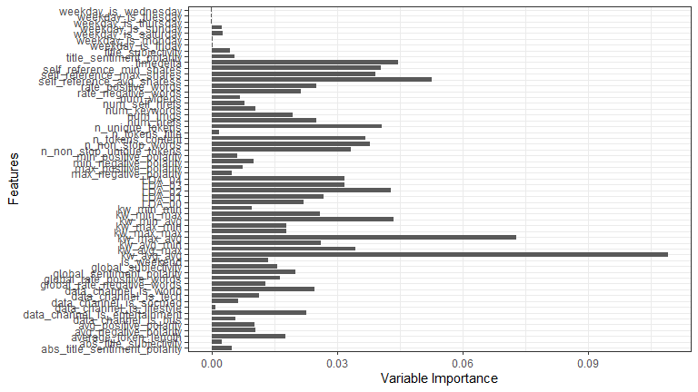

```r
p3_df <- data.frame(p3_m$variable.importance)
p3_df$var <- rownames(p3_df)
p3_df <- p3_df %>%
    rename(var_imp = p3_m.variable.importance)

ggplot(data = p3_df, aes(x = var, y = var_imp)) + geom_bar(stat = "identity",
    width = 0.75) + coord_flip() + labs(x = "Features", y = "Variable Importance") +
    theme_bw()
```

```r
p3_df %>%
    arrange(desc(var_imp))
```

|  | var_imp | var |
| --- | --- | --- |
| kw_avg_avg | 0.1091741 | kw_avg_avg |
| kw_max_avg | 0.0728707 | kw_max_avg |
| self_reference_avg_sharess | 0.0526362 | self_reference_avg_sharess |
| timedelta | 0.0445378 | timedelta |
| kw_min_avg | 0.0435581 | kw_min_avg |
| LDA_02 | 0.0429360 | LDA_02 |
| n_unique_tokens | 0.0406676 | n_unique_tokens |
| self_reference_min_shares | 0.0405638 | self_reference_min_shares |
| self_reference_max_shares | 0.0391437 | self_reference_max_shares |
| n_non_stop_words | 0.0378453 | n_non_stop_words |
| n_tokens_content | 0.0367418 | n_tokens_content |
| kw_avg_max | 0.0344124 | kw_avg_max |
| n_non_stop_unique_tokens | 0.0332221 | n_non_stop_unique_tokens |
| LDA_03 | 0.0318072 | LDA_03 |
| LDA_04 | 0.0318034 | LDA_04 |
| LDA_01 | 0.0268874 | LDA_01 |
| kw_avg_min | 0.0262239 | kw_avg_min |
| kw_min_max | 0.0260137 | kw_min_max |
| rate_positive_words | 0.0249833 | rate_positive_words |
| num_hrefs | 0.0249786 | num_hrefs |
| data_channel_is_world | 0.0246254 | data_channel_is_world |
| data_channel_is_entertainment | 0.0227449 | data_channel_is_entertainment |
| LDA_00 | 0.0219557 | LDA_00 |
| rate_negative_words | 0.0212840 | rate_negative_words |
| global_sentiment_polarity | 0.0199830 | global_sentiment_polarity |
| num_imgs | 0.0194752 | num_imgs |
| kw_max_max | 0.0179636 | kw_max_max |
| kw_max_min | 0.0179053 | kw_max_min |
| average_token_length | 0.0176895 | average_token_length |
| global_rate_positive_words | 0.0162743 | global_rate_positive_words |
| global_subjectivity | 0.0158309 | global_subjectivity |
| is_weekend | 0.0136376 | is_weekend |
| global_rate_negative_words | 0.0128621 | global_rate_negative_words |
| data_channel_is_tech | 0.0113039 | data_channel_is_tech |
| num_keywords | 0.0105658 | num_keywords |
| avg_negative_polarity | 0.0105049 | avg_negative_polarity |
| avg_positive_polarity | 0.0102221 | avg_positive_polarity |
| min_negative_polarity | 0.0100050 | min_negative_polarity |
| kw_min_min | 0.0097458 | kw_min_min |
| num_self_hrefs | 0.0079185 | num_self_hrefs |
| max_positive_polarity | 0.0075290 | max_positive_polarity |
| num_videos | 0.0067096 | num_videos |
| data_channel_is_socmed | 0.0064302 | data_channel_is_socmed |
| min_positive_polarity | 0.0060994 | min_positive_polarity |
| data_channel_is_bus | 0.0057785 | data_channel_is_bus |
| title_sentiment_polarity | 0.0055035 | title_sentiment_polarity |
| abs_title_sentiment_polarity | 0.0049479 | abs_title_sentiment_polarity |
| max_negative_polarity | 0.0048244 | max_negative_polarity |
| title_subjectivity | 0.0045096 | title_subjectivity |
| weekday_is_saturday | 0.0026729 | weekday_is_saturday |
| weekday_is_sunday | 0.0025016 | weekday_is_sunday |
| abs_title_subjectivity | 0.0024874 | abs_title_subjectivity |
| n_tokens_title | 0.0017311 | n_tokens_title |
| data_channel_is_lifestyle | 0.0008484 | data_channel_is_lifestyle |
| weekday_is_monday | 0.0003154 | weekday_is_monday |
| weekday_is_friday | 0.0001885 | weekday_is_friday |
| weekday_is_wednesday | -0.0000814 | weekday_is_wednesday |
| weekday_is_tuesday | -0.0000831 | weekday_is_tuesday |
| weekday_is_thursday | -0.0001016 | weekday_is_thursday |

According to the variable importance plot from above based on our optimal random forest model from problem 2 trained on a dataset of 30000 observations with the mtry value of 8, some of the most important predictors that dictate the predicted shares of an article are kw_avg_avg, kw_max_avg, self_reference_avg_sharess, kw_min_avg, LDA_02, and timedelta. Articles that are high in those features are likely to be shared more often than those that are not. However, since the random forest model is a good predictive model but not known as a good interpretable model, the important variable plot above may not be very accurate.

## Question 4 - Building a Predictive Model with a Subset of Predictors (25 pts.)

### Demonstration of our method for question 4 optimal model

```r
# There are mainly two parts in the work for question4:
# variable selection and model selection. In variable
# selection, we will use LASSO and random forest to have
# some potential optimal-subset of variables. Then, we will
# use splines plot from the GAM function to have a general
# picture of the relations between each variable and the
# log(share).Once we narrow down on 1/2 potential subset of
# variable, we will move on to the model selection part. We
# some analysis on what we got in the variable selection
# and previous work, we decide to apply non-linear model
# KNN and random forest to the subset of variables. With
# mse from each potential model, we will finalize the best
# model and make prediction on test data.
```

### Data ini & recode

```r
# take random sample data set for training & testing
set.seed(123)
train_df_q4 <- train_df[sample(x = nrow(train_df), size = 7500,
    replace = FALSE), ]
test_df_q4 <- train_df[sample(x = nrow(train_df), size = 2500,
    replace = FALSE), ]
# log(share) transformation
train_df_q4$shares <- log(train_df_q4$shares)
test_df_q4$shares <- log(test_df_q4$shares)
# drop variable url
train_df_q4 <- train_df_q4[, -1]
test_df_q4 <- test_df_q4[, -1]
# subset for later
test_df_q4_predictor <- data.matrix(train_df_q4[, -60])
test_df_q4_outcome <- data.matrix(train_df_q4$shares)
```

### Variable selection(at most 5 variables)

We will work on variables selections on LASSO and random forest, and using GAM to check the relationship between each variables and log(share).

#### LASSO variable selection

```r
# find optimal lambda
c_lasso_cv <- cv.glmnet(x = test_df_q4_predictor, y = test_df_q4_outcome,
    family = "gaussian", alpha = 1, nfolds = 10, type.measure = "mse")
optimalLambda <- c_lasso_cv$lambda.min  # the optimal lambda that minimize MSE
lasso_optimalModel <- glmnet(x = test_df_q4_predictor, y = test_df_q4_outcome,
    family = "gaussian", alpha = 1, lambda = optimalLambda)
opt_variableList <- lasso_optimalModel$beta
opt_variableList
```

```
## 59 x 1 sparse Matrix of class "dgCMatrix"
##                                          s0
## timedelta                      2.246689e-05
## n_tokens_title                 3.316522e-03
## n_tokens_content               4.727769e-05
## n_unique_tokens                .
## n_non_stop_words               .
## n_non_stop_unique_tokens       .
## num_hrefs                      5.629173e-03
## num_self_hrefs                -9.661969e-03
## num_imgs                       2.077648e-03
## num_videos                     3.057253e-03
## average_token_length          -9.642067e-02
## num_keywords                   1.542522e-02
## data_channel_is_lifestyle     -4.170802e-02
## data_channel_is_entertainment -1.623481e-01
## data_channel_is_bus           -6.005833e-02
## data_channel_is_socmed         2.818106e-01
## data_channel_is_tech           1.886000e-01
## data_channel_is_world         -2.234020e-02
## kw_min_min                     9.761268e-04
## kw_max_min                     1.325027e-06
## kw_avg_min                     .
## kw_min_max                    -1.894555e-07
## kw_max_max                     .
## kw_avg_max                    -3.538466e-08
## kw_min_avg                    -5.580335e-05
## kw_max_avg                    -3.547867e-05
## kw_avg_avg                     2.783238e-04
## self_reference_min_shares      6.948739e-07
## self_reference_max_shares      8.091132e-07
## self_reference_avg_sharess     .
## weekday_is_monday              3.094314e-02
## weekday_is_tuesday            -5.946870e-02
## weekday_is_wednesday          -4.104185e-02
## weekday_is_thursday           -1.058946e-02
## weekday_is_friday              1.190103e-03
## weekday_is_saturday            9.952380e-03
## weekday_is_sunday              .
## is_weekend                     3.059955e-01
## LDA_00                         1.627656e-01
## LDA_01                        -3.412608e-02
## LDA_02                        -1.415116e-01
## LDA_03                         .
## LDA_04                         .
## global_subjectivity            6.073350e-01
## global_sentiment_polarity     -5.771089e-01
## global_rate_positive_words     .
## global_rate_negative_words     .
## rate_positive_words            2.488495e-01
## rate_negative_words            .
## avg_positive_polarity          .
## min_positive_polarity         -4.367979e-02
## max_positive_polarity         -4.895250e-02
## avg_negative_polarity          .
## min_negative_polarity          .
## max_negative_polarity          .
## title_subjectivity             3.439329e-02
## title_sentiment_polarity       4.984278e-02
## abs_title_subjectivity         4.668683e-02
## abs_title_sentiment_polarity   5.095474e-02
```

#### Random Forest variables selection

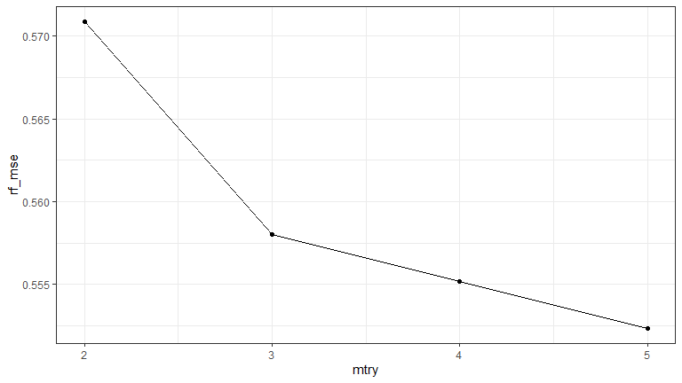

```r
# test and see how many variables we should include
oob <- c()
rf_mse <- c()
for (i in 2:5) {
    model <- ranger(data = train_df_q4, formula = shares ~ .,
        mtry = i, num.trees = 1000)
    oob <- c(oob, model$prediction.error)
    testPred <- predict(model, data = test_df_q4)
    rf_mse <- c(rf_mse, mse(test_df_q4$shares, testPred$predictions))
}
mtry <- c(2, 3, 4, 5)
RFepe <- data.frame(mtry, oob, rf_mse)
# mse suggests 5 variables
ggplot(data = RFepe) + geom_point(aes(x = mtry, y = rf_mse)) +
    geom_line(aes(x = mtry, y = rf_mse)) + theme_bw()
```

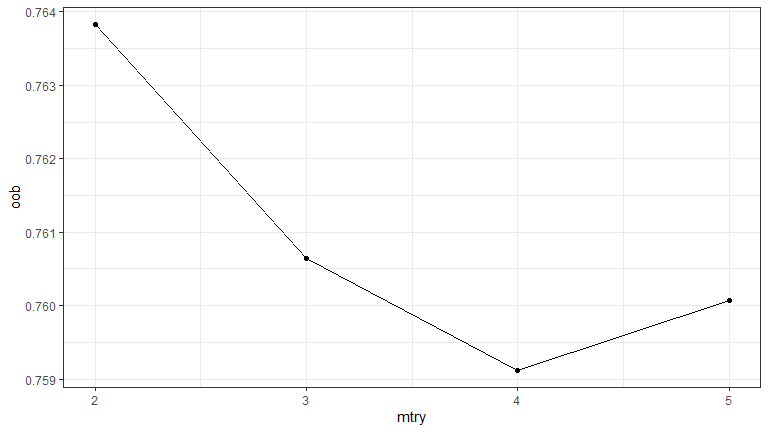

```r
# oob suggest 4 variables
ggplot(data = RFepe) + geom_point(aes(x = mtry, y = oob)) + geom_line(aes(x = mtry,
    y = oob)) + theme_bw()
```

```r
# RF model with 4 variables & 5 variables
RF_model_4 <- ranger(data = train_df_q4, formula = shares ~ .,
    mtry = 4, num.trees = 1000, importance = "permutation")
RF_model_5 <- ranger(data = train_df_q4, formula = shares ~ .,
    mtry = 5, num.trees = 1000, importance = "permutation")
# find the top-importance variables for each model we won't
# worry about the negative importance here as they're all
# generally small
varImportance4 <- data.frame(var_importance = RF_model_4$variable.importance)
arrange(varImportance4, desc(var_importance))
```

|  | var_importance |
| --- | --- |
| kw_avg_avg | 0.0530643 |
| kw_max_avg | 0.0389362 |
| self_reference_avg_sharess | 0.0339997 |
| n_non_stop_words | 0.0307584 |
| n_tokens_content | 0.0305429 |
| n_unique_tokens | 0.0284405 |
| self_reference_min_shares | 0.0280601 |
| LDA_02 | 0.0274108 |
| kw_min_avg | 0.0270979 |
| rate_positive_words | 0.0266119 |
| timedelta | 0.0248248 |
| rate_negative_words | 0.0244666 |
| n_non_stop_unique_tokens | 0.0239194 |
| self_reference_max_shares | 0.0219231 |
| num_hrefs | 0.0215332 |
| kw_avg_max | 0.0209939 |
| global_sentiment_polarity | 0.0202158 |
| LDA_04 | 0.0193916 |
| data_channel_is_world | 0.0193141 |
| num_imgs | 0.0183636 |
| LDA_03 | 0.0180236 |
| kw_avg_min | 0.0153831 |
| global_subjectivity | 0.0146372 |
| global_rate_negative_words | 0.0144945 |
| kw_min_max | 0.0143328 |
| LDA_00 | 0.0134773 |
| global_rate_positive_words | 0.0128565 |
| LDA_01 | 0.0126765 |
| average_token_length | 0.0121471 |
| kw_max_min | 0.0116917 |
| is_weekend | 0.0114496 |
| data_channel_is_entertainment | 0.0113977 |
| kw_max_max | 0.0092840 |
| min_negative_polarity | 0.0090466 |
| avg_positive_polarity | 0.0083923 |
| avg_negative_polarity | 0.0080591 |
| num_keywords | 0.0077109 |
| kw_min_min | 0.0074791 |
| min_positive_polarity | 0.0074038 |
| title_sentiment_polarity | 0.0072628 |
| abs_title_sentiment_polarity | 0.0069646 |
| max_positive_polarity | 0.0067889 |
| data_channel_is_tech | 0.0067550 |
| num_self_hrefs | 0.0054250 |
| title_subjectivity | 0.0050531 |
| max_negative_polarity | 0.0048151 |
| data_channel_is_socmed | 0.0047378 |
| weekday_is_saturday | 0.0041483 |
| num_videos | 0.0036558 |
| data_channel_is_bus | 0.0026756 |
| abs_title_subjectivity | 0.0026019 |
| weekday_is_sunday | 0.0024613 |
| n_tokens_title | 0.0015481 |
| weekday_is_tuesday | 0.0002355 |
| weekday_is_friday | 0.0001240 |
| data_channel_is_lifestyle | 0.0001000 |
| weekday_is_monday | -0.0000317 |
| weekday_is_thursday | -0.0000467 |
| weekday_is_wednesday | -0.0003001 |

```r
varImportance5 <- data.frame(var_importance = RF_model_5$variable.importance)
arrange(varImportance5, desc(var_importance))
```

|  | var_importance |
| --- | --- |
| kw_avg_avg | 0.0581468 |
| kw_max_avg | 0.0483108 |
| self_reference_avg_sharess | 0.0362324 |
| n_tokens_content | 0.0302671 |
| self_reference_min_shares | 0.0296697 |
| n_unique_tokens | 0.0290744 |
| n_non_stop_words | 0.0284637 |
| kw_min_avg | 0.0279523 |
| LDA_02 | 0.0275928 |
| n_non_stop_unique_tokens | 0.0264816 |
| timedelta | 0.0261229 |
| rate_negative_words | 0.0248559 |
| rate_positive_words | 0.0234656 |
| self_reference_max_shares | 0.0230083 |
| kw_avg_max | 0.0229536 |
| num_hrefs | 0.0222725 |
| LDA_04 | 0.0213069 |
| global_sentiment_polarity | 0.0209361 |
| data_channel_is_world | 0.0196208 |
| LDA_03 | 0.0183266 |
| LDA_00 | 0.0150382 |
| num_imgs | 0.0150359 |
| kw_min_max | 0.0147133 |
| kw_avg_min | 0.0142146 |
| average_token_length | 0.0139256 |
| global_rate_negative_words | 0.0139162 |
| global_rate_positive_words | 0.0139100 |
| data_channel_is_entertainment | 0.0133040 |
| LDA_01 | 0.0131275 |
| global_subjectivity | 0.0125912 |
| is_weekend | 0.0117197 |
| kw_max_min | 0.0116934 |
| kw_max_max | 0.0108933 |
| min_negative_polarity | 0.0097572 |
| avg_negative_polarity | 0.0088722 |
| avg_positive_polarity | 0.0085003 |
| num_keywords | 0.0083426 |
| kw_min_min | 0.0074823 |
| data_channel_is_tech | 0.0071087 |
| min_positive_polarity | 0.0067426 |
| abs_title_sentiment_polarity | 0.0060809 |
| max_positive_polarity | 0.0055516 |
| title_sentiment_polarity | 0.0054982 |
| num_self_hrefs | 0.0051855 |
| title_subjectivity | 0.0049824 |
| num_videos | 0.0047705 |
| data_channel_is_socmed | 0.0045678 |
| max_negative_polarity | 0.0042900 |
| weekday_is_saturday | 0.0038275 |
| data_channel_is_bus | 0.0032738 |
| weekday_is_sunday | 0.0026009 |
| abs_title_subjectivity | 0.0014119 |
| n_tokens_title | 0.0013438 |
| weekday_is_wednesday | 0.0001589 |
| data_channel_is_lifestyle | 0.0000522 |
| weekday_is_tuesday | -0.0001188 |
| weekday_is_thursday | -0.0001374 |
| weekday_is_friday | -0.0002619 |
| weekday_is_monday | -0.0005009 |

#### Variables selection sub-conclusion

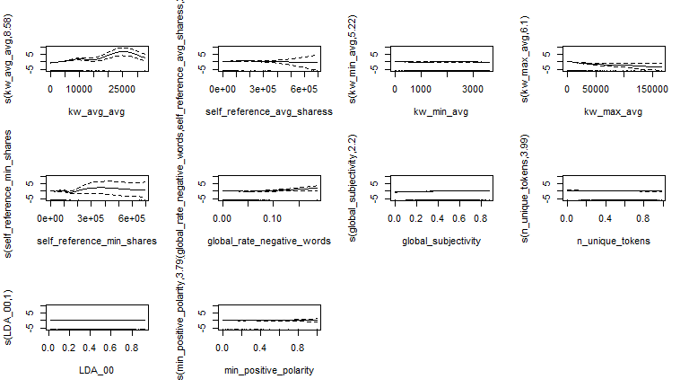

```r
# check suggested variable with spline and decide the final
# variable subset
checkGam <- gam(shares ~ s(kw_avg_avg) + s(self_reference_avg_sharess) +
    s(kw_min_avg) + s(kw_max_avg) + s(self_reference_min_shares) +
    s(global_rate_negative_words) + s(global_subjectivity) +
    s(n_unique_tokens) + s(LDA_00) + s(min_positive_polarity),
    data = train_df_q4, family = gaussian())
plot(checkGam, pages = 1)
```

We might don’t want to approach data analysis on this data set with linear approaches, since most splines don’t really show much linear relationship with share. we will move on with knn and random forest with both 4-variable and 5-variable data set

### Model selection

#### data recode with selected subset of data

```r
train_df_4RFvar <- data.frame(shares = train_df_q4$shares, kw_avg_avg = train_df_q4$kw_avg_avg,
    self_reference_avg_sharess = train_df_q4$self_reference_avg_sharess,
    kw_max_avg = train_df_q4$kw_max_avg, n_unique_tokens = train_df_q4$n_unique_tokens)
test_df_4RFvar <- data.frame(shares = test_df_q4$shares, kw_avg_avg = test_df_q4$kw_avg_avg,
    self_reference_avg_sharess = test_df_q4$self_reference_avg_sharess,
    kw_max_avg = test_df_q4$kw_max_avg, n_unique_tokens = test_df_q4$n_unique_tokens)
train_df_5RFvar <- data.frame(shares = train_df_q4$shares, kw_avg_avg = train_df_q4$kw_avg_avg,
    self_reference_avg_sharess = train_df_q4$self_reference_avg_sharess,
    kw_min_avg = train_df_q4$kw_min_avg, kw_max_avg = train_df_q4$kw_max_avg,
    self_reference_min_shares = train_df_q4$self_reference_min_shares)
test_df_5RFvar <- data.frame(shares = test_df_q4$shares, kw_avg_avg = test_df_q4$kw_avg_avg,
    self_reference_avg_sharess = test_df_q4$self_reference_avg_sharess,
    kw_min_avg = test_df_q4$kw_min_avg, kw_max_avg = test_df_q4$kw_max_avg,
    self_reference_min_shares = test_df_q4$self_reference_min_shares)
# list for oob and mse
mse <- c()
oob <- c()
modelName <- c()
# predictor and outcome df based on train_df_4RFvar and
# train_df_5RFvar train set
train_df_4RFvar_predictor <- data.matrix(train_df_4RFvar[, -1])
train_df_4RFvar_outcome <- data.matrix(train_df_4RFvar$shares)
train_df_5RFvar_predictor <- data.matrix(train_df_5RFvar[, -1])
train_df_5RFvar_outcome <- data.matrix(train_df_5RFvar$shares)
# test set
test_df_4RFvar_predictor <- data.matrix(test_df_4RFvar[, -1])
test_df_4RFvar_outcome <- data.matrix(test_df_4RFvar$shares)
test_df_5RFvar_predictor <- data.matrix(test_df_5RFvar[, -1])
test_df_5RFvar_outcome <- data.matrix(test_df_5RFvar$shares)
```

#### Random Forest model

```r
# random forest
RFmodel_selected_4var <- ranger(data = train_df_4RFvar, formula = shares ~
    ., mtry = 4, num.trees = 1000)
RFmodel_selected_5var <- ranger(data = train_df_5RFvar, formula = shares ~
    ., mtry = 5, num.trees = 1000)
# OOB
OOB_RF4var <- RFmodel_selected_4var$prediction.error
OOB_RF5var <- RFmodel_selected_5var$prediction.error
# out of sample MSE
MSE_RF4var <- mse(predict(RFmodel_selected_4var, data = test_df_4RFvar)$predictions,
    test_df_4RFvar$shares)
MSE_RF5var <- mse(predict(RFmodel_selected_5var, data = test_df_5RFvar)$predictions,
    test_df_5RFvar$shares)
oob <- c(oob, OOB_RF4var, OOB_RF5var)
mse <- c(mse, MSE_RF4var, MSE_RF5var)
modelName <- c(modelName, "RF4var", "RF5var")
```